# `residualPlots`: Residual Plots for Linear and Generalized Linear Models

Kevin O Brien

21 November 2018

#### Description

Plots the residuals versus each term in a mean function and versus fitted values. Also computes a curvature test for each of the plots by adding a quadratic term and testing the quadratic to be zero. For linear models, this is Tukey’s test for nonadditivity when plotting against fitted values.

#### Usage

```
### This is a generic function with only one required argument:
residualPlots (model, ...)
## Default S3 method:
residualPlots(model, terms = ~., layout = NULL, ask,
main = "", fitted = TRUE, AsIs=TRUE, plot = TRUE,
tests = TRUE, groups, ...)
## S3 method for class 'lm'
residualPlots(model, ...)
## S3 method for class 'glm'
residualPlots(model, ...)
### residualPlots calls residualPlot, so these arguments can be
### used with either function
residualPlot(model, ...)
## Default S3 method:
residualPlot(model, variable = "fitted", type = "pearson",
groups, plot = TRUE, linear = TRUE,
quadratic = if(missing(groups)) TRUE else FALSE,
smooth=FALSE, id=FALSE,
col = carPalette()[1], col.quad = carPalette()[2], pch=1,
xlab, ylab, lwd = 1, lty = 1,
grid=TRUE, key=!missing(groups), ...)
## S3 method for class 'lm'
residualPlot(model, ...)
## S3 method for class 'glm'
residualPlot(model, variable = "fitted", type = "pearson",
plot = TRUE, quadratic = FALSE, smooth=TRUE, ...)
residualPlots 103
```

#### Arguments

model A regression object. * `terms`: A one-sided formula that specifies a subset of the factors and the regressors that appear in the formula that defined the model. The default ~ . is to plot against all first-order terms, both regressors and factors. Higher order terms are skipped. For example, the specification terms = ~ . - X3 would plot against all regressors except for X3. To get a plot against fitted values only, use the arguments terms = ~ 1. Interactions are skipped. For polynomial terms, the plot is against the first-order variable (which may be centered and scaled depending on how the poly function is used). Plots against factors are boxplots. Plots against other matrix terms, like splines, use the result of predict(model), type=“terms”)[, variable]) as the horizontal axis; if the predict method doesn’t permit this type, then matrix terms are skipped. A grouping variable can also be specified in the terms, so, for example terms= ~ .|type would use the factor type to set a different color and symbol for each level of type. Any fits in the plots will also be done separately for each level of group. * `layout` : If set to a value like c(1, 1) or c(4, 3), the layout of the graph will have this many rows and columns. If not set, the program will select an appropriate layout. If the number of graphs exceed nine, you must select the layout yourself, or you will get a maximum of nine per page. If layout=NA, the function does not set the layout and the user can use the par function to control the layout, for example to have plots from two models in the same graphics window. ask If TRUE, ask the user before drawing the next plot; if FALSE, don’t ask. main Main title for the graphs. The default is main=“” for no title. fitted If TRUE, the default, include the plot against fitted values. AsIs If FALSE, terms that use the “as-is” function I are skipped; if TRUE, the default, they are included. plot If TRUE, draw the plot(s). tests If TRUE, display the curvature tests. With glm’s, the argument start is ignored in computing the curvature tests. … Additional arguments passed to residualPlot and then to plot. variable Quoted variable name for the factor or regressor to be put on the horizontal axis, or the default “fitted” to plot versus fitted values. type Type of residuals to be used. Pearson residuals are appropriate for lm objects since these are equivalent to ordinary residuals with ols and correctly weighted residuals with wls. Any quoted string that is an appropriate value of the type argument to residuals.lm or “rstudent” or “rstandard” for Studentized or standardized residuals. groups A grouping indicator. Points in different groups will be plotted with different colors and symbols. If missing, no grouping is used. In residualPlots, the grouping variable can also be set in the terms argument, as described above. The default is no grouping. If used, the groups argument shoud be a vector of values of the same length as the vector of residuals, for example groups = subject where subject indicates the grouping. 104 residualPlots linear If TRUE, adds a horizontal line at zero if no groups. With groups, display the within level of groups ols regression of the residuals as response and the horizontal axis as the regressor. quadratic if TRUE, fits the quadratic regression of the vertical axis on the horizontal axis and displays a lack of fit test. Default is TRUE for lm and FALSE for glm or if groups not missing. * `smooth`: specifies the smoother to be used along with its arguments; if FALSE, which is the default except for generalized linear models, no smoother is shown; can be a list giving the smoother function and its named arguments; TRUE is equivalent to list(smoother=loessLine, span=2/3, col=carPalette()[3]), which is the default for a GLM. See ScatterplotSmoothers for the smoothers supplied by the car package and their arguments. id controls point identification; if FALSE (the default), no points are identified; can be a list of named arguments to the showLabels function; TRUE is equivalent to list(method=“r”, n=2, cex=1, col=carPalette()[1], location=“lr”), which identifies the 2 points with the largest absolute residuals. col default color for points. If groups is set, col can be a list at least as long as the number of levels for groups giving the colors for each groups. col.quad default color for quadratic fit if groups is missing. Ignored if groups are used. pch plotting character. The default is pch=1. If groups are used, pch can be set to a vector at least as long as the number of groups. xlab X-axis label. If not specified, a useful label is constructed by the function. ylab Y-axis label. If not specified, a useful label is constructed by the function. lwd line width for lines. lty line type for quadratic. grid If TRUE, the default, a light-gray background grid is put on the graph key Should a key be added to the plot? Default is !is.null(groups).

#### Details

residualPlots draws one or more residuals plots depending on the value of the terms and fitted arguments. If terms = ~ ., the default, then a plot is produced of residuals versus each first-order term in the formula used to create the model. Interaction terms, spline terms, and polynomial terms of more than one predictor are skipped. In addition terms that use the “as-is” function, e.g., I(X^2), will also be skipped unless you set the argument AsIs=TRUE. A plot of residuals versus fitted values is also included unless fitted=FALSE. In addition to plots, a table of curvature tests is displayed. For plots against a term in the model formula, say X1, the test displayed is the t-test for for I(X1^2) in the fit of update, model, ~. + I(X1^2)). Econometricians call this a specification test. For factors, the displayed plot is a boxplot, no curvature test is computed, and grouping is ignored. For fitted values in a linear model, the test is Tukey’s one-degree-of-freedom test for nonadditivity. You can suppress the tests with the argument tests=FALSE. If grouping is used curvature tests are not displayed. residualPlot, which is called by residualPlots, should be viewed as an internal function, and is included here to display its arguments, which can be used with residualPlots as well. The residualPlot function returns the curvature test as an invisible result. S 105 residCurvTest computes the curvature test only. For any factors a boxplot will be drawn. For any polynomials, plots are against the linear term. Other non-standard predictors like B-splines are skipped. Value For lm objects, returns a data.frame with one row for each plot drawn, one column for the curvature test statistic, and a second column for the corresponding p-value. This function is used primarily for its side effect of drawing residual plots. Author(s) Sanford Weisberg, sandy@umn.edu

#### References

Fox, J. and Weisberg, S. (2019) An R Companion to Applied Regression, Third Edition. Sage. Weisberg, S. (2014) Applied Linear Regression, Fourth Edition, Wiley, Chapter 8 See Also See Also lm, identify, showLabels

#### Examples

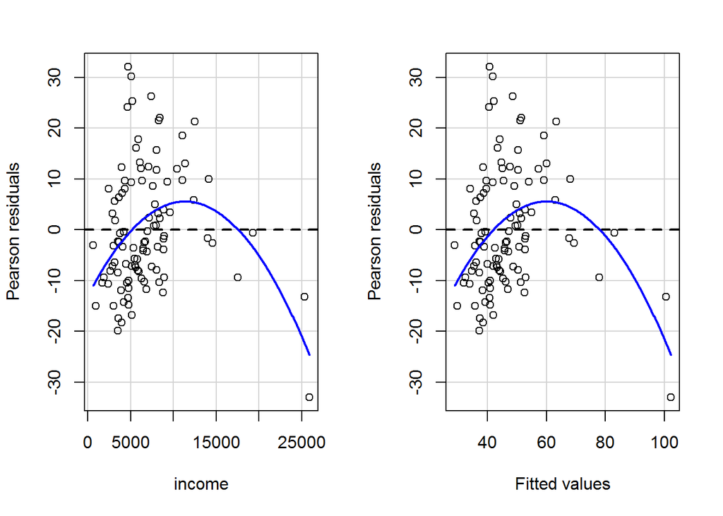

```
##            Test stat Pr(>|Test stat|)
## income       -4.5624        1.453e-05 ***
## Tukey test   -4.5624        5.057e-06 ***
## ---
## Signif. codes:  0 '***' 0.001 '**' 0.01 '*' 0.05 '.' 0.1 ' ' 1
```

```r
m1 <- lm(prestige ~ income, data=Prestige)
residualPlots(m1)
```

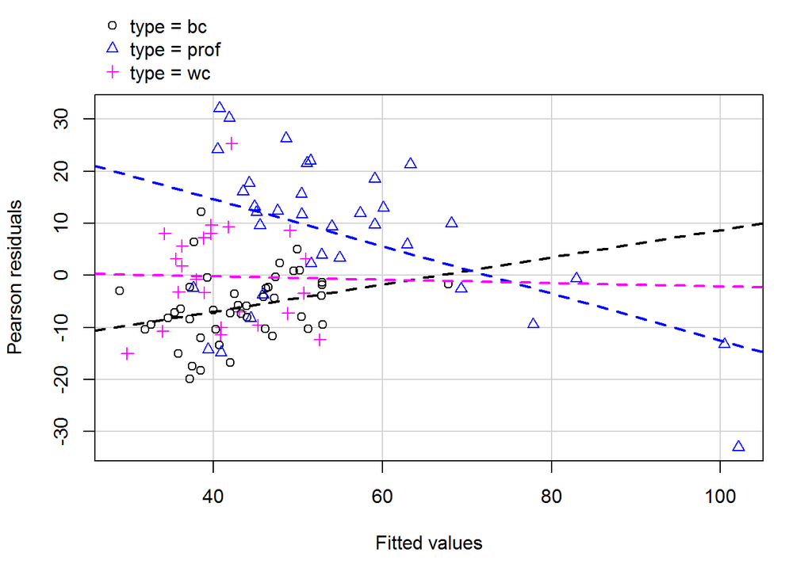

```r
residualPlots(m1, terms= ~ 1 | type) # plot vs. yhat grouping by type
```